# Machine Learning Engineer Nanodegree

## Project: Build a Digit Recognition Program

In this notebook, a template is provided for you to implement your functionality in stages which is required to successfully complete this project. If additional code is required that cannot be included in the notebook, be sure that the Python code is successfully imported and included in your submission, if necessary. Sections that begin with **'Implementation'** in the header indicate where you should begin your implementation for your project. Note that some sections of implementation are optional, and will be marked with **'Optional'** in the header.

In addition to implementing code, there will be questions that you must answer which relate to the project and your implementation. Each section where you will answer a question is preceded by a **'Question'** header. Carefully read each question and provide thorough answers in the following text boxes that begin with **'Answer:'**. Your project submission will be evaluated based on your answers to each of the questions and the implementation you provide.

> **Note:** Code and Markdown cells can be executed using the **Shift + Enter** keyboard shortcut. In addition, Markdown cells can be edited by typically double-clicking the cell to enter edit mode.

## Step 1: Design and Test a Model Architecture

Design and implement a deep learning model that learns to recognize sequences of digits. Train the model using synthetic data generated by concatenating character images from [notMNIST](http://yaroslavvb.blogspot.com/2011/09/notmnist-dataset.html) or [MNIST](http://yann.lecun.com/exdb/mnist/). To produce a synthetic sequence of digits for testing, you can for example limit yourself to sequences up to five digits, and use five classifiers on top of your deep network. You would have to incorporate an additional ‘blank’ character to account for shorter number sequences.

There are various aspects to consider when thinking about this problem:

- Your model can be derived from a deep neural net or a convolutional network.
- You could experiment sharing or not the weights between the softmax classifiers.
- You can also use a recurrent network in your deep neural net to replace the classification layers and directly emit the sequence of digits one-at-a-time.

You can use **Keras** to implement your model. Read more at [keras.io](https://keras.io/).

Here is an example of a [published baseline model on this problem](http://static.googleusercontent.com/media/research.google.com/en//pubs/archive/42241.pdf). ([video](https://www.youtube.com/watch?v=vGPI_JvLoN0)). You are not expected to model your architecture precisely using this model nor get the same performance levels, but this is more to show an exampe of an approach used to solve this particular problem. We encourage you to try out different architectures for yourself and see what works best for you. Here is a useful [forum post](https://discussions.udacity.com/t/goodfellow-et-al-2013-architecture/202363) discussing the architecture as described in the paper.

### Implementation

Use the code cell (or multiple code cells, if necessary) to implement the first step of your project. Once you have completed your implementation and are satisfied with the results, be sure to thoroughly answer the questions that follow.

```python
from keras.datasets import mnist
from keras.models import Model, load_model
from keras.layers import Dense, Dropout, Activation, Flatten, merge
from keras.layers import Input, Convolution2D, MaxPooling2D
from keras.layers.normalization import BatchNormalization
from keras.layers.local import LocallyConnected2D
from keras.utils.np_utils import to_categorical

import os
import sys
import tarfile
import numpy as np
from six.moves import cPickle as pickle
from six.moves.urllib.request import urlretrieve
from PIL import Image
from scipy.misc import imresize
from scipy import ndimage
import matplotlib.pyplot as plt
import h5py
import operator

%matplotlib inline
```

```python
def getAccuracy(clf, dataset, sequences, labels, fiveDigit=True):
    pred = clf.predict(dataset)
    acc = 0
    for sample in range(len(sequences)):
        pred_length = pred[0][sample]
        index0, value0 = max(enumerate(pred_length), key=operator.itemgetter(1))
        pred_d1 = pred[1][sample]
        index1, value1 = max(enumerate(pred_d1), key=operator.itemgetter(1))
        pred_d2 = pred[2][sample]
        index2, value2 = max(enumerate(pred_d2), key=operator.itemgetter(1))
        pred_d3 = pred[3][sample]
        index3, value3 = max(enumerate(pred_d3), key=operator.itemgetter(1))
        pred_d4 = pred[4][sample]
        index4, value4 = max(enumerate(pred_d4), key=operator.itemgetter(1))
        if fiveDigit:
            pred_d5 = pred[5][sample]
            index5, value5 = max(enumerate(pred_d5), key=operator.itemgetter(1))

        if fiveDigit and (sequences[sample, index0] == 1 and labels[sample, index1, 0] == 1 and
            labels[sample, index2, 1] == 1 and labels[sample, index3, 2] == 1 and
            labels[sample, index4, 3] == 1 and labels[sample, index5, 4] == 1):
            acc += 1
        if not fiveDigit and (sequences[sample, index0] == 1 and labels[sample, index1, 0] == 1 and
            labels[sample, index2, 1] == 1 and labels[sample, index3, 2] == 1 and
            labels[sample, index4, 3] == 1):
            acc += 1
    return 1. * acc / len(sequences)
```

```python
(X_train, y_train), (X_test, y_test) = mnist.load_data()

print(X_train.shape, y_train.shape)
print(X_test.shape, y_test.shape)
```

```
(60000, 28, 28) (60000,)
(10000, 28, 28) (10000,)
```

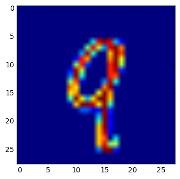

```python
image = np.array(X_train[np.random.randint(X_train.shape[0]), :, :])

plt.figure()
plt.imshow(image)
```

```python
# Don't run unless generating new data!

num_labels = 11 # 0-9 + blank
image_size = 28
new_image_size = 28

def seqLength(n):
    s = 1
    if n > 10:
        s += seqLength(n / 10)
    return s

def generateNewDataset(source_data, source_labels, sequences, max_sequence_length=5, option=1, insert_blanks=True):

    new_dataset = np.ndarray((sequences, 1, new_image_size, new_image_size), dtype=np.int8)
    new_labels = np.ndarray((sequences, num_labels, max_sequence_length), dtype=np.int8)
    sequence_lengths = np.ndarray((sequences, max_sequence_length), dtype=np.int8)

    # Support for option 2 below
    if option == 2:
        random_lengths = np.random.randint(1, max_sequence_length + 1, sequences)

    for sequence in range(sequences):

        # Option 1: Equal numbers of cases per class, except sequence_length
        if option == 1:
            number = np.random.randint(10 ** max_sequence_length)
            sequence_length = seqLength(number)

        # Option 2: Equal numbers of cases for each sequence_length - and each resized number
        if option == 2:
            sequence_length = random_lengths[sequence]

        # Save sequence length to return variable
        sequence_lengths[sequence, :] = 0
        sequence_lengths[sequence, sequence_length - 1] = 1

        # Randomly select samples from source data
        sample_indices = []
        for bar in range(sequence_length):
            sample_indices.append(np.random.randint(source_data.shape[0]))

        # Save label data from sources
        new_labels[sequence, :, :] = 0
        new_labels[sequence, 0, sequence_length:max_sequence_length] = 1 # Label "blank" classes
        for digit in range(sequence_length):
            new_labels[sequence, source_labels[sample_indices[digit]] + 1, digit] = 1

        # Pull the images from the original sources and concatenate
        sample = np.matrix(source_data[sample_indices[0], :, :])
        for character in sample_indices[1:]:
            sample = np.concatenate((sample, np.matrix(source_data[character, :, :])), axis=1)

        # Insert blanks to keep digits aligned
        if insert_blanks:
            for bar in range(max_sequence_length - sequence_length):
                sample = np.concatenate((sample, np.matrix([[0] * image_size] * image_size)), axis=1)

        # Resize sequence image to constant width
        new_image = imresize(sample, (new_image_size, new_image_size), interp='bilinear')

        # Append current sample to new data and label sets
        new_dataset[sequence, 0, :, :] = new_image

    return new_dataset, new_labels, sequence_lengths

new_train_dataset, new_train_labels, train_sequences = generateNewDataset(X_train, y_train, 5000000, 5, 1, True)
new_test_dataset, new_test_labels, test_sequences = generateNewDataset(X_test, y_test, 30000, 5, 1, True)

print("Generating sequence data complete.")
print(new_train_dataset.shape, new_train_labels.shape, train_sequences.shape)
print(new_test_dataset.shape, new_test_labels.shape, test_sequences.shape)
```

[output not shown]

```python
print(np.sum(new_train_labels, axis=0)) # Check distribution of classes
print("\n")
print(np.sum(train_sequences, axis=0)) # Check distribution of sequence lengths
```

```
[[     0    548   5065  50202 499113]
 [492771 492897 493405 487557 444618]
 [562559 562128 561580 556328 504790]
 [497234 496771 496023 492107 447744]
 [511250 510921 508887 506020 460438]
 [488280 487248 486689 481984 439078]
 [451408 450997 451687 447095 406590]
 [492828 492963 493540 488657 443633]
 [522042 522821 521004 516480 470587]
 [486983 487216 486752 482897 438424]
 [494645 495490 495368 490673 444985]]


[    548    4517   45137  448911 4500887]
```

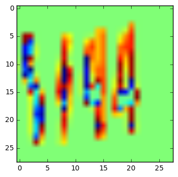

```python
image = np.array(new_train_dataset[np.random.randint(new_train_dataset.shape[0]), 0, :, :])

plt.figure()
plt.imshow(image)
```

```python
# Don't run unless saving a new batch of data!

pickle_file = 'MNISTseq28_xlg-3.pickle'

try:
  f = open(pickle_file, 'wb')
  save = {
    'train_dataset': new_train_dataset,
    'train_labels': new_train_labels,
    'train_sequences': train_sequences,
    'test_dataset': new_test_dataset,
    'test_labels': new_test_labels,
    'test_sequences': test_sequences,
    }
  pickle.dump(save, f, pickle.HIGHEST_PROTOCOL)
  f.close()
except Exception as e:
  print('Unable to save data to', pickle_file, ':', e)
  raise

statinfo = os.stat(pickle_file)
print('Compressed pickle size:', statinfo.st_size)
```

```
Compressed pickle size: 4245320505
```

```python
# Run this cell after the import statements if the sequence data is already pickled

pickle_file = 'MNISTseq28_xlg-3.pickle'
# Random numbers, with label for blank cases:                          'MNISTseq28_xlg-1.pickle'
# Random lengths, with label for blank cases:                          'MNISTseq28_xlg-2.pickle'
# Random numbers, with label for blank cases, and constant spacing:    'MNISTseq28_xlg-3.pickle'
# Random lengths, with label for blank cases, and constant spacing:    'MNISTseq28_xlg-4.pickle'

with open(pickle_file, 'rb') as f:
  save = pickle.load(f)
  train_dataset = save['train_dataset']
  train_labels = save['train_labels']
  train_sequences = save['train_sequences']
  test_dataset = save['test_dataset']
  test_labels = save['test_labels']
  test_sequences = save['test_sequences']
  del save  # hint to help gc free up memory

image_size = 28
# image_size = 64
num_labels = 11
max_sequence_length=5
num_channels = 1 # grayscale

print('Training set', train_dataset.shape, train_labels.shape, train_sequences.shape)
print('Test set', test_dataset.shape, test_labels.shape, test_sequences.shape)
```

```
Training set (5000000, 1, 28, 28) (5000000, 11, 5) (5000000, 5)
Test set (30000, 1, 28, 28) (30000, 11, 5) (30000, 5)
```

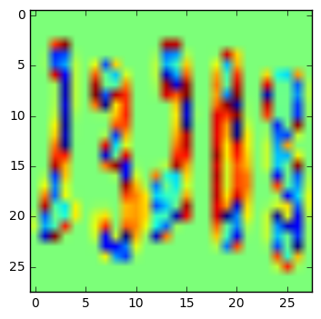

```python
image = np.array(train_dataset[np.random.randint(train_dataset.shape[0]), 0, :, :])

plt.figure()
plt.imshow(image)
```

```python
# Model adapted from "VGG-like convnet" at https://keras.io/getting-started/sequential-model-guide/
# and extended to mimic the Google Mult-digit classifier from the paper linked above

inputs = Input(shape=(num_channels, image_size, image_size))

c1 = Convolution2D(64, 5, 5, border_mode='same')(inputs)
a1 = Activation('relu')(c1)
mp1 = MaxPooling2D(pool_size=(2, 2), strides=(1, 1), border_mode='same')(a1)
bn1 = BatchNormalization()(mp1)

c2 = Convolution2D(96, 5, 5, border_mode='same')(bn1)
a2 = Activation('relu')(c2)
mp2 = MaxPooling2D(pool_size=(2, 2), strides=(2, 2), border_mode='same')(a2)
do2 = Dropout(0.25)(mp2)
bn2 = BatchNormalization()(do2)

c3 = Convolution2D(128, 5, 5, border_mode='same')(bn2)
a3 = Activation('relu')(c3)
mp3 = MaxPooling2D(pool_size=(2, 2), strides=(1, 1), border_mode='same')(a3)
do3 = Dropout(0.25)(mp3)
bn3 = BatchNormalization()(do3)

c4 = Convolution2D(160, 5, 5, border_mode='same')(bn3)
a4 = Activation('relu')(c4)
mp4 = MaxPooling2D(pool_size=(2, 2), strides=(2, 2), border_mode='same')(a4)
do4 = Dropout(0.25)(mp4)
bn4 = BatchNormalization()(do4)

c5 = Convolution2D(192, 5, 5, border_mode='same')(bn4)
a5 = Activation('relu')(c5)
mp5 = MaxPooling2D(pool_size=(2, 2), strides=(1, 1), border_mode='same')(a5)
do5 = Dropout(0.25)(mp5)
bn5 = BatchNormalization()(do5)

c6 = Convolution2D(192, 5, 5, border_mode='same')(bn5)
a6 = Activation('relu')(c6)
mp6 = MaxPooling2D(pool_size=(2, 2), strides=(2, 2), border_mode='same')(a6)
do6 = Dropout(0.25)(mp6)
bn6 = BatchNormalization()(do6)

c7 = Convolution2D(192, 5, 5, border_mode='same')(bn6)
a7 = Activation('relu')(c7)
mp7 = MaxPooling2D(pool_size=(2, 2), strides=(1, 1), border_mode='same')(a7)
do7 = Dropout(0.25)(mp7)
bn7 = BatchNormalization()(do7)

c8 = Convolution2D(192, 5, 5, border_mode='same')(bn7)
a8 = Activation('relu')(c8)
mp8 = MaxPooling2D(pool_size=(2, 2), strides=(2, 2), border_mode='same')(a8)
do8 = Dropout(0.25)(mp8)
bn8 = BatchNormalization()(do8)

fl = Flatten()(bn8)

d1 = Dense(1024)(fl)
a9 = Activation('relu')(d1)
do9 = Dropout(0.25)(a9)
bn9 = BatchNormalization()(do9)

d3 = Dense(max_sequence_length)(bn9)
bn10 = BatchNormalization()(d3)
L = Activation('softmax')(bn10) # <--- Sequence length representation

d4 = Dense(num_labels)(bn9)
bn11 = BatchNormalization()(d4)
S1 = Activation('softmax')(bn11) # First character/digit

d5 = Dense(num_labels)(bn9)
bn12 = BatchNormalization()(d5)
S2 = Activation('softmax')(bn12)

d6 = Dense(num_labels)(bn9)
bn13 = BatchNormalization()(d6)
S3 = Activation('softmax')(bn13)

d7 = Dense(num_labels)(bn9)
bn14 = BatchNormalization()(d7)
S4 = Activation('softmax')(bn14)

d8 = Dense(num_labels)(bn9)
bn15 = BatchNormalization()(d8)
S5 = Activation('softmax')(bn15)

clf = Model(input=inputs, output=[L, S1, S2, S3, S4, S5]) # Seq length + five channel output

clf.compile(loss='categorical_crossentropy', optimizer='adadelta',
            metrics=['categorical_accuracy'])

clf.fit(train_dataset, [train_sequences, train_labels[:,:,0], train_labels[:,:,1], train_labels[:,:,2],
                        train_labels[:,:,3], train_labels[:,:,4]], batch_size=100,
                        nb_epoch=14, validation_split=0.006, verbose=2)

clf.save('MNIST-xlg3-3.h5')
```

```
Train on 4970000 samples, validate on 30000 samples
```

```python
clf = load_model('MNIST-xlg3-1.h5') # xlg-3 dataset, conv: [48, 64, 128, 160...], dense: 1024, 3 epochs
# clf.summary()

evaluate = clf.evaluate(test_dataset, [test_sequences, test_labels[:,:,0], test_labels[:,:,1],
                            test_labels[:,:,2], test_labels[:,:,3], test_labels[:,:,4]])

print("\n", evaluate)

print("\n", getAccuracy(clf, test_dataset, test_sequences, test_labels))
```

```
 [0.54409647638797765, 2.4852262387867085e-05, 0.11416944639484088, 0.11118109554151694, 0.12973993959873914, 0.11220691709319751, 0.07677422573827207, 1.0, 0.96726666666666672, 0.96626666666666672, 0.96389999999999998, 0.96783333333333332, 0.97836666666666672]

 0.8521333333333333
```

```python
clf = load_model('MNIST-xlg3-2.h5') # xlg-3 dataset, conv: [64, 96, 128, 160...], dense: 1024, 3 epochs
# clf.summary()

evaluate = clf.evaluate(test_dataset, [test_sequences, test_labels[:,:,0], test_labels[:,:,1],
                            test_labels[:,:,2], test_labels[:,:,3], test_labels[:,:,4]])

print("\n", evaluate)

print("\n", getAccuracy(clf, test_dataset, test_sequences, test_labels))
```

```
 [0.3996232834537824, 2.1997499996602226e-05, 0.07616748333324988, 0.087261265190442402, 0.086968110142648214, 0.086207487228016064, 0.062996940180783473, 1.0, 0.97916666666666663, 0.97629999999999995, 0.97636666666666672, 0.97463333333333335, 0.98243333333333338]

 0.8936333333333333
```

```python
clf = load_model('MNIST-xlg3-3.h5') # xlg-3 dataset, conv: [64, 96, 128, 160...], dense: 1024, 14 epochs
# clf.summary()

evaluate = clf.evaluate(test_dataset, [test_sequences, test_labels[:,:,0], test_labels[:,:,1],
                            test_labels[:,:,2], test_labels[:,:,3], test_labels[:,:,4]])

print("\n", evaluate)

print("\n", getAccuracy(clf, test_dataset, test_sequences, test_labels))
```

```
 [0.30165003898739817, 1.6136313452079775e-06, 0.066508378997072584, 0.069316450391709805, 0.069766459177434445, 0.053716146163642405, 0.042340990265769263, 1.0, 0.98150000000000004, 0.98033333333333328, 0.97950000000000004, 0.98423333333333329, 0.98796666666666666]

 0.9164333333333333
```

### Question 1

*What approach did you take in coming up with a solution to this problem?*

**Answer:** I first designed a multilayer convolutional network, based on the Keras documentation (https://keras.io/getting-started/sequential-model-guide/#examples), and made certain it performed well on single digits from the Keras MNIST dataset.

Next I modified the data sets to use random combinations of up to five samples from the MNIST data and added parallel softmax outputs in a similar fashion to the Google architecture linked above. This model was almost 80% accurate on 5-digit combinations and >95% per digit accuracy.

Adding in additional convoluational layers to more closely match the Google architecture produced 85.2% accuracy (MNIST-xlg3-1 above).

After making some modifications using for the SVHN data, I retested training on this dataset with the different layer sizes and achieved **91.6%** accuracy on 5-digit combinations and ~98% accuracy on each digit (MNIST-xlg3-3 above).

### Question 2

*What does your final architecture look like? (Type of model, layers, sizes, connectivity, etc.)*

```python
clf = load_model('MNIST-xlg3-3.h5')
clf.summary()
```

```
____________________________________________________________________________________________________
Layer (type)                     Output Shape          Param #     Connected to
====================================================================================================
input_1 (InputLayer)             (None, 1, 28, 28)     0
____________________________________________________________________________________________________
convolution2d_1 (Convolution2D)  (None, 1, 28, 64)     44864       input_1[0][0]
____________________________________________________________________________________________________
activation_1 (Activation)        (None, 1, 28, 64)     0           convolution2d_1[0][0]
____________________________________________________________________________________________________
maxpooling2d_1 (MaxPooling2D)    (None, 1, 28, 64)     0           activation_1[0][0]
____________________________________________________________________________________________________
batchnormalization_1 (BatchNorma (None, 1, 28, 64)     256         maxpooling2d_1[0][0]
____________________________________________________________________________________________________
convolution2d_2 (Convolution2D)  (None, 1, 28, 96)     153696      batchnormalization_1[0][0]
____________________________________________________________________________________________________
activation_2 (Activation)        (None, 1, 28, 96)     0           convolution2d_2[0][0]
____________________________________________________________________________________________________
maxpooling2d_2 (MaxPooling2D)    (None, 1, 14, 96)     0           activation_2[0][0]
____________________________________________________________________________________________________
dropout_1 (Dropout)              (None, 1, 14, 96)     0           maxpooling2d_2[0][0]
____________________________________________________________________________________________________
batchnormalization_2 (BatchNorma (None, 1, 14, 96)     384         dropout_1[0][0]
____________________________________________________________________________________________________
convolution2d_3 (Convolution2D)  (None, 1, 14, 128)    307328      batchnormalization_2[0][0]
____________________________________________________________________________________________________
activation_3 (Activation)        (None, 1, 14, 128)    0           convolution2d_3[0][0]
____________________________________________________________________________________________________
maxpooling2d_3 (MaxPooling2D)    (None, 1, 14, 128)    0           activation_3[0][0]
____________________________________________________________________________________________________
dropout_2 (Dropout)              (None, 1, 14, 128)    0           maxpooling2d_3[0][0]
____________________________________________________________________________________________________
batchnormalization_3 (BatchNorma (None, 1, 14, 128)    512         dropout_2[0][0]
____________________________________________________________________________________________________
convolution2d_4 (Convolution2D)  (None, 1, 14, 160)    512160      batchnormalization_3[0][0]
____________________________________________________________________________________________________
activation_4 (Activation)        (None, 1, 14, 160)    0           convolution2d_4[0][0]
____________________________________________________________________________________________________
maxpooling2d_4 (MaxPooling2D)    (None, 1, 7, 160)     0           activation_4[0][0]
____________________________________________________________________________________________________
dropout_3 (Dropout)              (None, 1, 7, 160)     0           maxpooling2d_4[0][0]
```

[output cut: 78 more lines]

```
____________________________________________________________________________________________________
activation_11 (Activation)       (None, 11)            0           batchnormalization_11[0][0]
____________________________________________________________________________________________________
activation_12 (Activation)       (None, 11)            0           batchnormalization_12[0][0]
____________________________________________________________________________________________________
activation_13 (Activation)       (None, 11)            0           batchnormalization_13[0][0]
____________________________________________________________________________________________________
activation_14 (Activation)       (None, 11)            0           batchnormalization_14[0][0]
____________________________________________________________________________________________________
activation_15 (Activation)       (None, 11)            0           batchnormalization_15[0][0]
====================================================================================================
Total params: 5,016,556
Trainable params: 5,011,956
Non-trainable params: 4,600
____________________________________________________________________________________________________
```

### Question 3

*How did you train your model? How did you generate your synthetic dataset?* Include examples of images from the synthetic data you constructed.

**Answer:** I trained my model using the adadelta optimizer. Researching similar image classification problems indicated that Adam and Adadelta are common choices for this type of application. I chose to use a batch size of 100, but didn't thoroughly test adjusting this parameter.

I tested generating my synthetic dataset a few different ways, but settled on randomly generating numbers between 0 and 99,999, using the length of that number to then grab a matching number of random samples from the training or test sets, concatenating those images together, then resizing the resulting image back to 28x28. In the cases where less than five digits were used, I inserted blank space into the image so that there is more consistency in the shape of the numbers. 5,000,000 new training samples were generated using the original training data and 30,000 new testing samples were generated using the original testing data.

Samples of generated images can be found below.

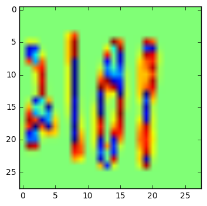

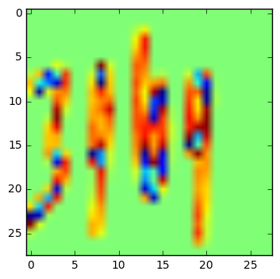

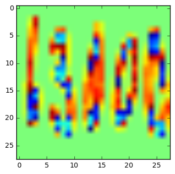

```python
image = np.array(train_dataset[np.random.randint(train_dataset.shape[0]), 0, :, :])

plt.figure()
plt.imshow(image)

image = np.array(train_dataset[np.random.randint(train_dataset.shape[0]), 0, :, :])

plt.figure()
plt.imshow(image)

image = np.array(train_dataset[np.random.randint(train_dataset.shape[0]), 0, :, :])

plt.figure()
plt.imshow(image)
```

## Step 2: Train a Model on a Realistic Dataset

Once you have settled on a good architecture, you can train your model on real data. In particular, the [Street View House Numbers (SVHN)](http://ufldl.stanford.edu/housenumbers/) dataset is a good large-scale dataset collected from house numbers in Google Street View. Training on this more challenging dataset, where the digits are not neatly lined-up and have various skews, fonts and colors, likely means you have to do some hyperparameter exploration to perform well.

### Implementation

Use the code cell (or multiple code cells, if necessary) to implement the first step of your project. Once you have completed your implementation and are satisfied with the results, be sure to thoroughly answer the questions that follow.

```python
url = 'http://ufldl.stanford.edu/housenumbers/'

def get_SVHN(filename, expected_bytes, force=False):
  if force or not os.path.exists(filename):
    print('Downloading:', filename)
    filename, _ = urlretrieve(url + filename, filename)
    print('Download Complete')
  statinfo = os.stat(filename)
  if statinfo.st_size == expected_bytes:
    print('Found and verified', filename)
  else:
    raise Exception(
      'Failed to verify ' + filename + '. Can you get to it with a browser?')
  return filename

train_filename = get_SVHN('train.tar.gz', 404141560)
test_filename = get_SVHN('test.tar.gz', 276555967)
extra_filename = get_SVHN('extra.tar.gz', 1955489752)
```

```
Found and verified train.tar.gz
Found and verified test.tar.gz
Found and verified extra.tar.gz
```

```python
def extract(filename, force=False):
  root = os.path.splitext(os.path.splitext(filename)[0])[0]  # remove .tar.gz
  if os.path.isdir(root) and not force:
    print('%s already present - Skipping extraction of %s.' % (root, filename))
  else:
    print('Extracting data for %s. This may take a while. Please wait.' % root)
    tar = tarfile.open(filename)
    sys.stdout.flush()
    tar.extractall()
    tar.close()
  data_folders = root
  print(data_folders, "data extraction complete.")
  return data_folders

train_folders = extract(train_filename)
test_folders = extract(test_filename)
extra_folders = extract(extra_filename)
```

```
train already present - Skipping extraction of train.tar.gz.
train data extraction complete.
test already present - Skipping extraction of test.tar.gz.
test data extraction complete.
extra already present - Skipping extraction of extra.tar.gz.
extra data extraction complete.
```

```python
# Don't run unless you need to generate a new set of dictionaries

def digitStruct_name(sample, hdf5_data):
    name_obj = hdf5_data['digitStruct']['name']
    name = ''.join([chr(value[0]) for value in hdf5_data[name_obj[sample][0]].value])
    return name

def digitStruct_bbox(sample, hdf5_data):
    def get_values(member, obj):
        value = []
        if obj.shape[0] > 1:
            for character in range(obj.shape[0]):
                value.append(int(hdf5_data[obj[character][0]][0][0]))
        else:
            value.append(int(obj[0][0]))
        box_info[member] = value

    box_info = {}
    box_info['label'] = []
    box_info['top'] = []
    box_info['left'] = []
    box_info['height'] = []
    box_info['width'] = []

    bbox = hdf5_data['digitStruct']['bbox'][sample]
    hdf5_data[bbox[0]].visititems(get_values)
    return box_info

def createDictionary(struct):
    dictionary = {}
    len_samples = struct['digitStruct']['name'].size
    for sample in range(len_samples):
        image_name = digitStruct_name(sample, struct)
        image_bbox = digitStruct_bbox(sample, struct)
        dictionary[image_name] = image_bbox
    return dictionary, len_samples

train_struct = h5py.File('TrainDigitStruct.mat')
train_dictionary, train_samples = createDictionary(train_struct)
print("Train dictionary complete.")
print("Train samples:", train_samples)

test_struct = h5py.File('TestDigitStruct.mat')
test_dictionary, test_samples = createDictionary(test_struct)
print("Test dictionary complete.")
print("Test samples:", test_samples)

extra_struct = h5py.File('ExtraDigitStruct.mat')
extra_dictionary, extra_samples = createDictionary(extra_struct)
print("Extra dictionary complete.")
print("Extra samples:", extra_samples)
```

```
Train dictionary complete.
Train samples: 33402
Test dictionary complete.
Test samples: 13068
Extra dictionary complete.
Extra samples: 202353
```

```python
# Only run to save a new set of dictionaries

pickle_file = 'SVHN-dictionaries.pickle'

try:
    f = open(pickle_file, 'wb')
    save = {
        'train_dictionary': train_dictionary,
        'test_dictionary': test_dictionary,
        'extra_dictionary': extra_dictionary,
    }
    pickle.dump(save, f, pickle.HIGHEST_PROTOCOL)
    f.close()
except Exception as e:
    print('Unable to save data to', pickle_file, ':', e)
    raise

statinfo = os.stat(pickle_file)
print('Compressed pickle size:', statinfo.st_size)
```

```
Compressed pickle size: 17739007
```

```python
# Run to load dictionaries

pickle_file = 'SVHN-dictionaries.pickle'

with open(pickle_file, 'rb') as f:
  save = pickle.load(f)
  train_dictionary = save['train_dictionary']
  test_dictionary = save['test_dictionary']
  extra_dictionary = save['extra_dictionary']
  del save  # hint to help gc free up memory

print("Train dictionary:", len(train_dictionary))
print("Test dictionary:", len(test_dictionary))
print("Extra dictionary:", len(extra_dictionary))
```

```
Train dictionary: 33402
Test dictionary: 13068
Extra dictionary: 202353
```

```python
# Don't run unless you need to generate a new data set

image_size = 32
# pixel_depth = 255.0
pixel_channels = 1
max_sequence_length = 5
num_labels = 11

def load_images(folder, dictionary, crop=False):
    image_files = os.listdir(folder)

    dataset = np.ndarray(shape=(len(image_files), pixel_channels, image_size, image_size), dtype=np.int32)
    labels = np.ndarray(shape=(len(image_files), num_labels, max_sequence_length), dtype=np.int32)
    sequences = np.ndarray(shape=(len(image_files), max_sequence_length), dtype=np.int32)

    num_images = 0
    skipped_images = 0
    for image in image_files:
        if image in dictionary:
            label_sequence = dictionary[image]['label']
        else:
            label_sequence = None
            skipped_images += 1

        if len(label_sequence) > max_sequence_length:
            label_sequence = None
            skipped_images += 1
            print("Image", image, "has too many digits!")

        if label_sequence != None and len(label_sequence) > 0:
            image_file = os.path.join(folder, image)
            # image_data = (ndimage.imread(image_file).astype(float) - pixel_depth / 2) / pixel_depth
            image_raw = ndimage.imread(image_file, flatten=True)

            if crop:
                lefts = dictionary[image]['left']
                tops = dictionary[image]['top']
                widths = dictionary[image]['width']
                heights = dictionary[image]['height']
                rights = []
                bottoms = []
                for left, width in zip(lefts, widths):
                    rights.append(left + width)
                for top, height in zip(tops, heights):
                    bottoms.append(top + height)
                if min(tops) < max(bottoms) and min(lefts) < max(rights):
                    image_data = image_raw[min(tops):max(bottoms), min(lefts):max(rights)]
                else:
                    print("Bounding box error!")
            else:
                image_data = image_raw

            #print(image_data.shape)
            if min(image_data.shape) > 0:
                resized_image = imresize(image_data, (image_size, image_size), interp='bilinear')
                dataset[num_images, 0, :, :] = resized_image

                labels[num_images, :, :] = 0
                if len(label_sequence) < max_sequence_length:
                    labels[num_images, 0, len(label_sequence):] = 1 # Blank class labels
                for index in range(len(label_sequence)):
                    labels[num_images, label_sequence[index], index] = 1

                sequences[num_images, :] = 0
                sequences[num_images, len(label_sequence) - 1] = 1

                num_images += 1
            else:
                skipped_images += 1

                print("Skipped zero-size bbox image:", image)

    print('\nSkipped images:', skipped_images)
    print('Full dataset tensor:', dataset.shape)
    print('Mean:', np.mean(dataset))
    print('Standard deviation:', np.std(dataset), "\n")

    dataset = dataset[0:num_images, :, :, :]
    labels = labels[0:num_images, :, :]
    sequences = sequences[0:num_images, :]

    return dataset, labels, sequences

train_dataset, train_labels, train_sequences = load_images('train', train_dictionary, crop=True)
test_dataset, test_labels, test_sequences = load_images('test', test_dictionary, crop=True)
extra_dataset, extra_labels, extra_sequences = load_images('extra', extra_dictionary, crop=True)
print("Done.")
```

```python
# Resample the data to even out class representation - ultimately not used.

new_length = 250000

new_train_dataset = np.ndarray((new_length, pixel_channels, image_size, image_size), dtype=np.int32)
new_train_labels = np.ndarray((new_length, num_labels, max_sequence_length), dtype=np.int32)
new_train_sequences = np.ndarray((new_length, max_sequence_length), dtype=np.int32)

# class_length = [new_length * 0.001, new_length * 0.009, new_length * 0.09, new_length * 0.9]
class_length = [new_length / max_sequence_length, new_length / max_sequence_length,
                new_length / max_sequence_length, new_length / max_sequence_length]
collected_samples = [0, 0, 0, 0]
collected_total = 0

while collected_total < new_length:
    random_sample = np.random.randint(len(train_sequences))
    if ((train_sequences[random_sample][0] == 1 and collected_samples[0] < class_length[0]) or
        (train_sequences[random_sample][1] == 1 and collected_samples[1] < class_length[1]) or
        (train_sequences[random_sample][2] == 1 and collected_samples[2] < class_length[2]) or
        (train_sequences[random_sample][3] == 1 and collected_samples[3] < class_length[3])):

        new_train_dataset[collected_total, :, :, :] = train_dataset[random_sample, :, :, :]
        new_train_labels[collected_total, :, :] = train_labels[random_sample, :, :]
        new_train_sequences[collected_total, :] = train_sequences[random_sample, :]
        collected_samples[:] += train_sequences[random_sample, :]
        collected_total += 1

train_dataset = new_train_dataset
train_labels = new_train_labels
train_sequences = new_train_sequences

print("Done.")
```

```
Done.
```

```python
# Don't run unless you are saving new data

pickle_file = 'SVHN-xlg-11.pickle'

try:
    f = open(pickle_file, 'wb')
    save = {
        'train_dataset': train_dataset,
        'train_labels': train_labels,
        'train_sequences': train_sequences,
        'test_dataset': test_dataset,
        'test_labels': test_labels,
        'test_sequences': test_sequences,
        'extra_dataset': extra_dataset,
        'extra_labels': extra_labels,
        'extra_sequences': extra_sequences,
    }
    pickle.dump(save, f, pickle.HIGHEST_PROTOCOL)
    f.close()
except Exception as e:
    print('Unable to save data to', pickle_file, ':', e)
    raise

statinfo = os.stat(pickle_file)
print('Compressed pickle size:', statinfo.st_size)
```

```
Compressed pickle size: 1077739512
```

```python
# Run after import statement to load data

# pickle_file = 'SVHN-xlg-9.pickle' # 32x32 greyscale, original datasets, sequence lengths up to 5
pickle_file = 'SVHN-xlg-11.pickle' # 32x32 greyscale, cropped datasets, sequence lengths up to 5

with open(pickle_file, 'rb') as f:
  save = pickle.load(f)
  train_dataset = save['train_dataset']
  train_labels = save['train_labels']
  train_sequences = save['train_sequences']
  test_dataset = save['test_dataset']
  test_labels = save['test_labels']
  test_sequences = save['test_sequences']
  extra_dataset = save['extra_dataset']
  extra_labels = save['extra_labels']
  extra_sequences = save['extra_sequences']
  del save  # hint to help gc free up memory

image_size = 32
num_channels = 1
num_labels = 11
max_sequence_length=5

print('Training set', train_dataset.shape, train_labels.shape, train_sequences.shape)
print('Test set', test_dataset.shape, test_labels.shape, test_sequences.shape)
print('Extra set', extra_dataset.shape, extra_labels.shape, extra_sequences.shape)

print('Training sequence distribution:', sum(train_sequences))
print('Testing sequence distribution:', sum(test_sequences))
print('Extra sequence distribution:', sum(extra_sequences))

print('\n\n', sum(train_labels))
print('\n\n', sum(test_labels))
print('\n\n', sum(extra_labels))
```

```
Training set (33372, 1, 32, 32) (33372, 11, 5) (33372, 5)
Test set (13060, 1, 32, 32) (13060, 11, 5) (13060, 5)
Extra set (202124, 1, 32, 32) (202124, 11, 5) (202124, 5)
Training sequence distribution: [ 5133 18111  8685  1434     9]
Testing sequence distribution: [2482 8350 2080  146    2]
Extra sequence distribution: [  9383  71683 106633  14310    115]


 [[    0  5133 23244 31929 33363]
 [ 9233  3327  1128   156     2]
 [ 6316  3128   983   150     0]
 [ 4342  2966  1057   120     2]
 [ 3509  2807   979   160     0]
 [ 2828  2867  1045   134     1]
 [ 2152  2489   953   130     0]
 [ 1877  2633   960   115     2]
 [ 1582  2378   939   140     0]
 [ 1449  2281   805   121     1]
 [   84  3363  1279   217     1]]


 [[    0  2482 10832 12912 13058]
 [ 3693  1144   244    17     0]
 [ 2655  1232   243    16     0]
 [ 1625  1026   217    13     0]
 [ 1235  1080   198     9     0]
 [ 1051  1078   242    12     0]
 [  856   918   182    17     0]
 [  747  1018   239    12     1]
 [  623   835   192     8     0]
 [  556   848   176    15     0]
 [   19  1399   295    29     1]]


 [[     0   9383  81066 187699 202009]
 [ 56295  21012  11671   1463     12]
 [ 39446  22005  11897   1285      7]
 [ 27556  20148  11644   1343      9]
 [ 21312  18130   9970   1149      8]
 [ 16592  20030  14975   1802     11]
 [ 12293  16999  10987   1241     14]
 [ 11937  18664  11934   1391     14]
 [  8530  15632  10006   1147      7]
 [  7624  15121  10476   1165     15]
 [   539  25000  17498   2439     18]]
```

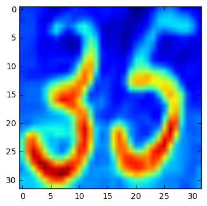

```python
image = np.array(extra_dataset[np.random.randint(extra_dataset.shape[0]), 0, :, :])
plt.figure()
plt.imshow(image)
```

```python
inputs = Input(shape=(num_channels, image_size, image_size))

c1 = Convolution2D(64, 5, 5, border_mode='same')(inputs) # Originally 48
a1 = Activation('relu')(c1)
mp1 = MaxPooling2D(pool_size=(2, 2), strides=(1, 1), border_mode='same')(a1)
bn1 = BatchNormalization()(mp1)

c2 = Convolution2D(96, 5, 5, border_mode='same')(bn1) # Originally 64
a2 = Activation('relu')(c2)
mp2 = MaxPooling2D(pool_size=(2, 2), strides=(2, 2), border_mode='same')(a2)
do2 = Dropout(0.25)(mp2)
bn2 = BatchNormalization()(do2)

c3 = Convolution2D(128, 5, 5, border_mode='same')(bn2)
a3 = Activation('relu')(c3)
mp3 = MaxPooling2D(pool_size=(2, 2), strides=(1, 1), border_mode='same')(a3)
do3 = Dropout(0.25)(mp3)
bn3 = BatchNormalization()(do3)

c4 = Convolution2D(160, 5, 5, border_mode='same')(bn3)
a4 = Activation('relu')(c4)
mp4 = MaxPooling2D(pool_size=(2, 2), strides=(2, 2), border_mode='same')(a4)
do4 = Dropout(0.25)(mp4)
bn4 = BatchNormalization()(do4)

c5 = Convolution2D(192, 5, 5, border_mode='same')(bn4)
a5 = Activation('relu')(c5)
mp5 = MaxPooling2D(pool_size=(2, 2), strides=(1, 1), border_mode='same')(a5)
do5 = Dropout(0.25)(mp5)
bn5 = BatchNormalization()(do5)

c6 = Convolution2D(192, 5, 5, border_mode='same')(bn5)
a6 = Activation('relu')(c6)
mp6 = MaxPooling2D(pool_size=(2, 2), strides=(2, 2), border_mode='same')(a6)
do6 = Dropout(0.25)(mp6)
bn6 = BatchNormalization()(do6)

c7 = Convolution2D(192, 5, 5, border_mode='same')(bn6)
a7 = Activation('relu')(c7)
mp7 = MaxPooling2D(pool_size=(2, 2), strides=(1, 1), border_mode='same')(a7)
do7 = Dropout(0.25)(mp7)
bn7 = BatchNormalization()(do7)

c8 = Convolution2D(192, 5, 5, border_mode='same')(bn7)
a8 = Activation('relu')(c8)
mp8 = MaxPooling2D(pool_size=(2, 2), strides=(2, 2), border_mode='same')(a8)
do8 = Dropout(0.25)(mp8)
bn8 = BatchNormalization()(do8)

fl = Flatten()(bn8)

d1 = Dense(256)(fl)
a9 = Activation('relu')(d1)
do9 = Dropout(0.25)(a9)
bn9 = BatchNormalization()(do9)

d3 = Dense(max_sequence_length)(bn9)
bn10 = BatchNormalization()(d3)
L = Activation('softmax')(bn10) # <--- Sequence length representation

d4 = Dense(num_labels)(bn9)
bn11 = BatchNormalization()(d4)
S1 = Activation('softmax')(bn11) # First character/digit

d5 = Dense(num_labels)(bn9)
bn12 = BatchNormalization()(d5)
S2 = Activation('softmax')(bn12)

d6 = Dense(num_labels)(bn9)
bn13 = BatchNormalization()(d6)
S3 = Activation('softmax')(bn13)

d7 = Dense(num_labels)(bn9)
bn14 = BatchNormalization()(d7)
S4 = Activation('softmax')(bn14)

d8 = Dense(num_labels)(bn9)
bn15 = BatchNormalization()(d8)
S5 = Activation('softmax')(bn15)

clf = Model(input=inputs, output=[L, S1, S2, S3, S4, S5]) # Seq length + five channel output

clf.compile(loss='categorical_crossentropy', optimizer='adadelta',
            metrics=['categorical_accuracy'])

clf.fit(train_dataset, [train_sequences, train_labels[:,:,0], train_labels[:,:,1], train_labels[:,:,2],
                        train_labels[:,:,3], train_labels[:,:,4]
                       ], batch_size=100, nb_epoch=250, validation_split=0.03, verbose=2)

# clf.fit(extra_dataset, [extra_sequences, extra_labels[:,:,0], extra_labels[:,:,1], extra_labels[:,:,2],
#                         extra_labels[:,:,3], extra_labels[:,:,4]
#                        ], batch_size=100, nb_epoch=10, validation_split=0.03, verbose=2)

clf.save('SVHN-12c.h5')
print("Training complete.")
```

```
Train on 32370 samples, validate on 1002 samples
30s - loss: 11.8794 - activation_199_loss: 1.0077 - activation_200_loss: 2.2669 - activation_201_loss: 2.1805 - activation_202_loss: 1.8354 - activation_203_loss: 2.2891 - activation_204_loss: 2.2998 - activation_199_categorical_accuracy: 0.7277 - activation_200_categorical_accuracy: 0.2463 - activa…
16s - loss: 9.5643 - activation_199_loss: 0.6821 - activation_200_loss: 1.6491 - activation_201_loss: 2.0021 - activation_202_loss: 1.4649 - activation_203_loss: 1.8520 - activation_204_loss: 1.9142 - activation_199_categorical_accuracy: 0.8534 - activation_200_categorical_accuracy: 0.4921 - activat…
16s - loss: 7.9617 - activation_199_loss: 0.5271 - activation_200_loss: 1.3055 - activation_201_loss: 1.8820 - activation_202_loss: 1.2580 - activation_203_loss: 1.4426 - activation_204_loss: 1.5464 - activation_199_categorical_accuracy: 0.8881 - activation_200_categorical_accuracy: 0.6167 - activat…
16s - loss: 6.7042 - activation_199_loss: 0.4355 - activation_200_loss: 1.1262 - activation_201_loss: 1.7131 - activation_202_loss: 1.1187 - activation_203_loss: 1.1166 - activation_204_loss: 1.1941 - activation_199_categorical_accuracy: 0.8990 - activation_200_categorical_accuracy: 0.6763 - activat…
16s - loss: 5.6654 - activation_199_loss: 0.3693 - activation_200_loss: 1.0015 - activation_201_loss: 1.5386 - activation_202_loss: 1.0170 - activation_203_loss: 0.8517 - activation_204_loss: 0.8873 - activation_199_categorical_accuracy: 0.9123 - activation_200_categorical_accuracy: 0.7103 - activat…
16s - loss: 4.8963 - activation_199_loss: 0.3241 - activation_200_loss: 0.9105 - activation_201_loss: 1.4092 - activation_202_loss: 0.9545 - activation_203_loss: 0.6554 - activation_204_loss: 0.6426 - activation_199_categorical_accuracy: 0.9180 - activation_200_categorical_accuracy: 0.7350 - activat…
16s - loss: 4.3148 - activation_199_loss: 0.2915 - activation_200_loss: 0.8422 - activation_201_loss: 1.2938 - activation_202_loss: 0.9114 - activation_203_loss: 0.5160 - activation_204_loss: 0.4600 - activation_199_categorical_accuracy: 0.9238 - activation_200_categorical_accuracy: 0.7533 - activat…
16s - loss: 3.9007 - activation_199_loss: 0.2704 - activation_200_loss: 0.7928 - activation_201_loss: 1.2109 - activation_202_loss: 0.8808 - activation_203_loss: 0.4171 - activation_204_loss: 0.3287 - activation_199_categorical_accuracy: 0.9251 - activation_200_categorical_accuracy: 0.7692 - activat…
16s - loss: 3.5603 - activation_199_loss: 0.2502 - activation_200_loss: 0.7493 - activation_201_loss: 1.1282 - activation_202_loss: 0.8580 - activation_203_loss: 0.3392 - activation_204_loss: 0.2355 - activation_199_categorical_accuracy: 0.9307 - activation_200_categorical_accuracy: 0.7786 - activat…
16s - loss: 3.3314 - activation_199_loss: 0.2365 - activation_200_loss: 0.7206 - activation_201_loss: 1.0693 - activation_202_loss: 0.8468 - activation_203_loss: 0.2888 - activation_204_loss: 0.1694 - activation_199_categorical_accuracy: 0.9310 - activation_200_categorical_accuracy: 0.7877 - activat…
16s - loss: 3.1246 - activation_199_loss: 0.2232 - activation_200_loss: 0.6916 - activation_201_loss: 1.0055 - activation_202_loss: 0.8299 - activation_203_loss: 0.2521 - activation_204_loss: 0.1223 - activation_199_categorical_accuracy: 0.9336 - activation_200_categorical_accuracy: 0.7950 - activat…
16s - loss: 2.9714 - activation_199_loss: 0.2084 - activation_200_loss: 0.6674 - activation_201_loss: 0.9612 - activation_202_loss: 0.8171 - activation_203_loss: 0.2287 - activation_204_loss: 0.0886 - activation_199_categorical_accuracy: 0.9383 - activation_200_categorical_accuracy: 0.8009 - activat…
16s - loss: 2.8595 - activation_199_loss: 0.2008 - activation_200_loss: 0.6481 - activation_201_loss: 0.9278 - activation_202_loss: 0.8113 - activation_203_loss: 0.2071 - activation_204_loss: 0.0644 - activation_199_categorical_accuracy: 0.9396 - activation_200_categorical_accuracy: 0.8083 - activat…
16s - loss: 2.7478 - activation_199_loss: 0.1909 - activation_200_loss: 0.6207 - activation_201_loss: 0.8934 - activation_202_loss: 0.8024 - activation_203_loss: 0.1934 - activation_204_loss: 0.0470 - activation_199_categorical_accuracy: 0.9416 - activation_200_categorical_accuracy: 0.8162 - activat…
16s - loss: 2.6603 - activation_199_loss: 0.1851 - activation_200_loss: 0.6068 - activation_201_loss: 0.8547 - activation_202_loss: 0.7985 - activation_203_loss: 0.1807 - activation_204_loss: 0.0345 - activation_199_categorical_accuracy: 0.9439 - activation_200_categorical_accuracy: 0.8192 - activat…
16s - loss: 2.5956 - activation_199_loss: 0.1838 - activation_200_loss: 0.5905 - activation_201_loss: 0.8316 - activation_202_loss: 0.7913 - activation_203_loss: 0.1728 - activation_204_loss: 0.0256 - activation_199_categorical_accuracy: 0.9425 - activation_200_categorical_accuracy: 0.8235 - activat…
```

[output cut: 235 more lines]

```python
clf = load_model('SVHN-1.h5') # Train dataset, conv: [48, 64, 128, 160], dense: 1024, 40 epochs
# clf.summary()

evaluate = clf.evaluate(test_dataset, [test_sequences, test_labels[:,:,0], test_labels[:,:,1],
                            test_labels[:,:,2], test_labels[:,:,3], test_labels[:,:,4]])

print("\n", evaluate)

print("\n", getAccuracy(clf, test_dataset, test_sequences, test_labels))
```

```
 [5.4023998311290615, 0.89545653230887801, 1.5376569079009992, 1.9811692382350112, 0.88891074060481512, 0.097007146513960141, 0.0021992563879725136, 0.59825528010995077, 0.48278236914600553, 0.33379247015610652, 0.81802877259247153, 0.98813896541169266, 0.99984695439240889]

 0.17393633302724212
```

```python
clf = load_model('SVHN-2.h5') # Extra dataset, conv: [48, 64, 128, 160], dense: 1024, 10 epochs
# clf.summary()

evaluate = clf.evaluate(test_dataset, [test_sequences, test_labels[:,:,0], test_labels[:,:,1],
                            test_labels[:,:,2], test_labels[:,:,3], test_labels[:,:,4]])

print("\n", evaluate)

print("\n", getAccuracy(clf, test_dataset, test_sequences, test_labels))
```

```
 [5.3829847497242396, 0.79433079940082463, 1.6010016901324493, 2.103443737018353, 0.79029882971321652, 0.091895836446506091, 0.0020138699997727877, 0.68992959903875262, 0.47497704317710582, 0.27578818487909396, 0.82024793390254203, 0.98836853382307932, 0.99984695439240889]

 0.14072543617998162
```

```python
clf = load_model('SVHN-3.h5') # Extra dataset, conv: [48, 64, 128, 160], dense: 3096, 10 epochs
# clf.summary()

evaluate = clf.evaluate(test_dataset, [test_sequences, test_labels[:,:,0], test_labels[:,:,1],
                            test_labels[:,:,2], test_labels[:,:,3], test_labels[:,:,4]])

print("\n", evaluate)

print("\n", getAccuracy(clf, test_dataset, test_sequences, test_labels))
```

```
 [5.4958253646794537, 0.83648692247952972, 1.6547261319249493, 2.0859525640842049, 0.82337394244524187, 0.093327031160964496, 0.0019587966610032856, 0.66819712277906618, 0.44872972146611639, 0.28466483012393667, 0.81290174473817101, 0.98806244260789711, 0.99984695439240889]

 0.14776553412917048
```

```python
clf = load_model('SVHN-4.h5') # Train dataset, conv: [64, 96, 128, 160], dense: 1024, 40 epochs
# clf.summary()

evaluate = clf.evaluate(test_dataset, [test_sequences, test_labels[:,:,0], test_labels[:,:,1],
                            test_labels[:,:,2], test_labels[:,:,3], test_labels[:,:,4]])

print("\n", evaluate)

print("\n", getAccuracy(clf, test_dataset, test_sequences, test_labels))
```

```
 [5.3566485807222071, 0.90016449924488839, 1.5096203635729231, 1.9428244316508583, 0.9062082461527009, 0.095636448673253979, 0.002194597963731192, 0.60108662385038547, 0.49464340374343507, 0.35445362718546103, 0.80517294155482233, 0.98806244260789711, 0.99984695439240889]

 0.19344964799510253
```

```python
clf = load_model('SVHN-5.h5') # Extra dataset, conv: [64, 96, 128, 160], dense: 1024, 10 epochs
# clf.summary()

evaluate = clf.evaluate(test_dataset, [test_sequences, test_labels[:,:,0], test_labels[:,:,1],
                            test_labels[:,:,2], test_labels[:,:,3], test_labels[:,:,4]])

print("\n", evaluate)

print("\n", getAccuracy(clf, test_dataset, test_sequences, test_labels))
```

```
 [5.3647891287778835, 0.81150033731580251, 1.5841829306056896, 2.0719198378576649, 0.80267874876001322, 0.092408624945198733, 0.0020986455578908877, 0.67638506276694355, 0.48270584635133224, 0.29040404041316265, 0.8161922253013788, 0.98790939700030611, 0.99984695439240889]

 0.1605448423630242
```

```python
clf = load_model('SVHN-6.h5') # Train dataset, conv: [64, 96, 128, 160], dense: 1024, 100 epochs
# clf.summary()

evaluate = clf.evaluate(test_dataset, [test_sequences, test_labels[:,:,0], test_labels[:,:,1],
                            test_labels[:,:,2], test_labels[:,:,3], test_labels[:,:,4]])

print("\n", evaluate)

print("\n", getAccuracy(clf, test_dataset, test_sequences, test_labels))
```

```
 [5.3822789122140984, 1.022771981775414, 1.4367137944110862, 1.8509641392427298, 0.9710760029368638, 0.098779990443549903, 0.0019730056232501523, 0.56718702173247626, 0.51729415369427889, 0.39623507806238212, 0.77701254975806688, 0.98699112335475969, 0.99984695439240889]

 0.23752678298132843
```

```python
clf = load_model('SVHN-7.h5') # Extra dataset, four digits, conv: [64, 96, 128, 160], dense: 1024, 10 epochs
# clf.summary()

evaluate = clf.evaluate(test_dataset, [test_sequences, test_labels[:,:,0], test_labels[:,:,1],
                            test_labels[:,:,2], test_labels[:,:,3]]) # , test_labels[:,:,4]])

print("\n", evaluate)

print("\n", getAccuracy(clf, test_dataset, test_sequences, test_labels, False))
```

```
 [5.9029104382999451, 0.99733911769670747, 1.6613468179362629, 2.1789863711382953, 0.95013083516410968, 0.11510726918329392, 0.56934027246288077, 0.45660492882518006, 0.25179856115107913, 0.79488749424166394, 0.98652992499617331]

 0.1165620694933415
```

```python
clf = load_model('SVHN-8.h5') # Test dataset, conv: [64, 96, 128, 160], dense: [1024, 32], 100 epochs
# clf.summary()

evaluate = clf.evaluate(test_dataset, [test_sequences, test_labels[:,:,0], test_labels[:,:,1],
                            test_labels[:,:,2], test_labels[:,:,3], test_labels[:,:,4]])

print("\n", evaluate)

print("\n", getAccuracy(clf, test_dataset, test_sequences, test_labels))
```

```
 [5.6521925035878935, 1.0234676511564276, 1.4769880512565656, 2.0100597023124682, 1.0395258394884415, 0.10031086809529527, 0.001840389468449869, 0.57468625652268279, 0.50826446282816184, 0.32177838996020813, 0.76714110806844338, 0.98660850933578204, 0.99984695439240889]

 0.17408937863483318
```

```python
clf = load_model('SVHN-11U.h5') # Train dataset, conv: [64, 96, 128, 160], dense: [1024], 1000 epochs
# clf.summary()

evaluate = clf.evaluate(test_dataset, [test_sequences, test_labels[:,:,0], test_labels[:,:,1],
                            test_labels[:,:,2], test_labels[:,:,3], test_labels[:,:,4]])

print("\n", evaluate)

print("\n", getAccuracy(clf, test_dataset, test_sequences, test_labels))
```

```
 [5.9935061106230823, 1.2553664758587089, 1.5148939248579227, 1.9902323795671233, 1.1090106558901913, 0.1216867978320499, 0.002315892412652793, 0.62641567190670622, 0.52142638508099315, 0.42332415059687789, 0.70630547903275176, 0.9781910009182736, 0.99984695439240889]

 0.2793847566574839
```

```python
clf = load_model('SVHN-12a.h5') # Cropped train/test dataset, conv: [64, 96, 128, 160], dense: [1024], 250 epochs
# clf.summary()

evaluate = clf.evaluate(test_dataset, [test_sequences, test_labels[:,:,0], test_labels[:,:,1],
                            test_labels[:,:,2], test_labels[:,:,3], test_labels[:,:,4]])

print("\n", evaluate)

print("\n", getAccuracy(clf, test_dataset, test_sequences, test_labels))
```

```
 [1.4434079218969593, 0.20537929126092877, 0.38610828528547969, 0.49591675640795535, 0.30867956973046101, 0.046051249914776937, 0.0012727662626481693, 0.94693721286370602, 0.89073506891271059, 0.86003062787136297, 0.91470137825421138, 0.98828483920367538, 0.99984686064318529]

 0.7523736600306279
```

```python
clf = load_model('SVHN-12b.h5') # Cropped train/test dataset, conv: [64, 96, 128, 160], dense: [512], 250 epochs
# clf.summary()

evaluate = clf.evaluate(test_dataset, [test_sequences, test_labels[:,:,0], test_labels[:,:,1],
                            test_labels[:,:,2], test_labels[:,:,3], test_labels[:,:,4]])
print("\n", evaluate)

print("\n", getAccuracy(clf, test_dataset, test_sequences, test_labels))
```

```
 [1.3343730165801406, 0.17028896259835666, 0.36629781244341553, 0.49120927232147904, 0.2673709402701947, 0.037837364154034915, 0.0013686625027319896, 0.95589586523736603, 0.89724349157733541, 0.86408882082695249, 0.926416539050536, 0.98996937212863712, 0.99984686064318529]

 0.7601837672281776
```

```python
clf = load_model('SVHN-12c.h5') # Cropped train/test dataset, conv: [64, 96, 128, 160], dense: [256], 250 epochs
# clf.summary()

evaluate = clf.evaluate(test_dataset, [test_sequences, test_labels[:,:,0], test_labels[:,:,1],
                            test_labels[:,:,2], test_labels[:,:,3], test_labels[:,:,4]])
print("\n", evaluate)

print("\n", getAccuracy(clf, test_dataset, test_sequences, test_labels))
```

```
 [1.321543351614457, 0.16379813994834547, 0.3718822260823309, 0.48231387058041908, 0.25926245285938304, 0.042968315488537974, 0.0013183501290462204, 0.95612557427258804, 0.89425727411944866, 0.86707503828483923, 0.92840735068912705, 0.98820826952526797, 0.99984686064318529]

 0.7630168453292496
```

```python
clf = load_model('SVHN-12U.h5') # Cropped train/test dataset, conv: [64, 96, 128, 160], dense: [3096], 1000 epochs
# clf.summary()

evaluate = clf.evaluate(test_dataset, [test_sequences, test_labels[:,:,0], test_labels[:,:,1],
                            test_labels[:,:,2], test_labels[:,:,3], test_labels[:,:,4]])
print("\n", evaluate)

print("\n", getAccuracy(clf, test_dataset, test_sequences, test_labels))
```

```
 [1.3552613628859906, 0.16975789204106628, 0.3889779130738219, 0.4956417370992634, 0.25763597559048079, 0.040823862122055882, 0.002423983919869247, 0.95666156202143948, 0.89486983154670752, 0.87281776416539048, 0.93261868300153139, 0.99027565084226643, 0.99977029096477799]

 0.7747320061255742
```

```python
clf = load_model('SVHN-12U.h5')
clf.summary()
```

```
____________________________________________________________________________________________________
Layer (type)                     Output Shape          Param #     Connected to
====================================================================================================
input_5 (InputLayer)             (None, 1, 32, 32)     0
____________________________________________________________________________________________________
convolution2d_33 (Convolution2D) (None, 1, 32, 64)     51264       input_5[0][0]
____________________________________________________________________________________________________
activation_61 (Activation)       (None, 1, 32, 64)     0           convolution2d_33[0][0]
____________________________________________________________________________________________________
maxpooling2d_33 (MaxPooling2D)   (None, 1, 32, 64)     0           activation_61[0][0]
____________________________________________________________________________________________________
batchnormalization_61 (BatchNorm (None, 1, 32, 64)     256         maxpooling2d_33[0][0]
____________________________________________________________________________________________________
convolution2d_34 (Convolution2D) (None, 1, 32, 96)     153696      batchnormalization_61[0][0]
____________________________________________________________________________________________________
activation_62 (Activation)       (None, 1, 32, 96)     0           convolution2d_34[0][0]
____________________________________________________________________________________________________
maxpooling2d_34 (MaxPooling2D)   (None, 1, 16, 96)     0           activation_62[0][0]
____________________________________________________________________________________________________
dropout_33 (Dropout)             (None, 1, 16, 96)     0           maxpooling2d_34[0][0]
____________________________________________________________________________________________________
batchnormalization_62 (BatchNorm (None, 1, 16, 96)     384         dropout_33[0][0]
____________________________________________________________________________________________________
convolution2d_35 (Convolution2D) (None, 1, 16, 128)    307328      batchnormalization_62[0][0]
____________________________________________________________________________________________________
activation_63 (Activation)       (None, 1, 16, 128)    0           convolution2d_35[0][0]
____________________________________________________________________________________________________
maxpooling2d_35 (MaxPooling2D)   (None, 1, 16, 128)    0           activation_63[0][0]
____________________________________________________________________________________________________
dropout_34 (Dropout)             (None, 1, 16, 128)    0           maxpooling2d_35[0][0]
____________________________________________________________________________________________________
batchnormalization_63 (BatchNorm (None, 1, 16, 128)    512         dropout_34[0][0]
____________________________________________________________________________________________________
convolution2d_36 (Convolution2D) (None, 1, 16, 160)    512160      batchnormalization_63[0][0]
____________________________________________________________________________________________________
activation_64 (Activation)       (None, 1, 16, 160)    0           convolution2d_36[0][0]
____________________________________________________________________________________________________
maxpooling2d_36 (MaxPooling2D)   (None, 1, 8, 160)     0           activation_64[0][0]
____________________________________________________________________________________________________
dropout_35 (Dropout)             (None, 1, 8, 160)     0           maxpooling2d_36[0][0]
```

[output cut: 78 more lines]

```
____________________________________________________________________________________________________
activation_71 (Activation)       (None, 11)            0           batchnormalization_71[0][0]
____________________________________________________________________________________________________
activation_72 (Activation)       (None, 11)            0           batchnormalization_72[0][0]
____________________________________________________________________________________________________
activation_73 (Activation)       (None, 11)            0           batchnormalization_73[0][0]
____________________________________________________________________________________________________
activation_74 (Activation)       (None, 11)            0           batchnormalization_74[0][0]
____________________________________________________________________________________________________
activation_75 (Activation)       (None, 11)            0           batchnormalization_75[0][0]
====================================================================================================
Total params: 5,953,284
Trainable params: 5,944,540
Non-trainable params: 8,744
____________________________________________________________________________________________________
```

### Question 4

*Describe how you set up the training and testing data for your model. How does the model perform on a realistic dataset?*

**Answer:** To prepare the training and testing data, I looped through all of the files in the two directories and pulled each image's sequence information from the digitStruct files. To make the images consistent, I resized them all to 32x32 and also converted them to greyscale.

Using the same model that achieved 85% accuracy on the previous dataset, the SVHN data was only able to produce an accuracy of 17.4%.

### Question 5

*What changes did you have to make, if any, to achieve "good" results? Were there any options you explored that made the results worse?*

**Answer:** I tested many different options for improving performance, but ultimately it came down to improving the dataset.

Increasing the large dense layer from 1024 nodes to 3096 decreased accuracy on the test set to 14%.

Increasing the number of nodes in the first two convolutional layers increased the test set accuracy to 19.3%. This change was then implmented on the MNIST sequence set and increased accuracy on the generated data from 85% to 92%.

Switching to training on the "extra" dataset lowered accuracy to 16%.

Resampling the "extra" dataset to have even numbers of cases for each sequence length lowered accuracy to 14.1%.

Increasing the numbers of epochs of training from 40 to 100 on the train set increased accuracy to 23.8%.

Reformatting the "extra" set to only use sequences of four or less numbers lowered accuracy to 11%.

Adding an extra dense layer with 32 nodes between the 1024-node dense layer and the output layers lowered accuracy to 17.4%.

Increasing the number of training epochs to 1000 (~6 hours on a GPU), using the original training data, increased the accuracy on the test set to 27.9%.

Ultimately, the biggest improvement came from re-generating the test set data to crop to the bounding boxes before resizing to 32x32 pixels. Reducing the large dense layer led to small improvements in test accuracy, but the best model came from increasing the dense layer size to 3096 nodes and running it much longer (1000 epochs). This produced an accuracy of 77.5%.

### Question 6

*What were your initial and final results with testing on a realistic dataset? Do you believe your model is doing a good enough job at classifying numbers correctly?*

**Answer:** Initial result: 17.4% accuracy. Final result: 77.5% accuracy. This model is still not doing a good enough job at classifying numbers to be very useful in a real world application, but is sufficiently good to attempt classifying pictures of numbers that I take myself.

## Step 3: Test a Model on Newly-Captured Images

Take several pictures of numbers that you find around you (at least five), and run them through your classifier on your computer to produce example results. Alternatively (optionally), you can try using OpenCV / SimpleCV / Pygame to capture live images from a webcam and run those through your classifier.

### Implementation

Use the code cell (or multiple code cells, if necessary) to implement the first step of your project. Once you have completed your implementation and are satisfied with the results, be sure to thoroughly answer the questions that follow.

```python
# Run to load photo data

image_size = 32
pixel_channels = 1
max_sequence_length = 5
num_labels = 11

def load_images(folder):
    image_files = os.listdir(folder)

    dataset = np.ndarray(shape=(len(image_files), pixel_channels, image_size, image_size), dtype=np.int32)
    labels = np.ndarray(shape=(len(image_files), num_labels, max_sequence_length), dtype=np.int32)
    sequences = np.ndarray(shape=(len(image_files), max_sequence_length), dtype=np.int32)

    dataset = dataset[:, :, :, :]

    num_images = 0
    skipped_images = 0
    for image in image_files:
        image_file = os.path.join(folder, image)
        image_data = ndimage.imread(image_file, flatten=True)

        if min(image_data.shape) > 0:
            resized_image = imresize(image_data, (image_size, image_size), interp='bilinear')
            dataset[num_images, 0, :, :] = resized_image
            num_images += 1
        else:
            print("Image not loaded!")

    labels[:, :, :] = 0
    # 10
    labels[0, 1, 0] = 1
    labels[0, 10, 1] = 1
    labels[0, 0, 2:] = 1
    # 117
    labels[1, 1, 0] = 1
    labels[1, 1, 1] = 1
    labels[1, 7, 2] = 1
    labels[1, 0, 3:] = 1
    # 14
    labels[2, 1, 0] = 1
    labels[2, 4, 1] = 1
    labels[2, 0, 2:] = 1
    # 2000
    labels[3, 2, 0] = 1
    labels[3, 10, 1] = 1
    labels[3, 10, 2] = 1
    labels[3, 10, 3] = 1
    labels[3, 0, 4] = 1
    # 24
    labels[4, 2, 0] = 1
    labels[4, 4, 1] = 1
    labels[4, 0, 2:] = 1
    # 25
    labels[5, 2, 0] = 1
    labels[5, 5, 1] = 1
    labels[5, 0, 2:] = 1
    # 3
    labels[6, 3, 0] = 1
    labels[6, 0, 1:] = 1
    # 34
    labels[7, 3, 0] = 1
    labels[7, 4, 1] = 1
    labels[7, 0, 2:] = 1

    sequences[:, :] = 0

    #10
    sequences[0, 1] = 1
    #117
    sequences[1, 2] = 1
    #14
    sequences[2, 1] = 1
    #2000
    sequences[3, 3] = 1
    #24
    sequences[4, 1] = 1
    #25
    sequences[5, 1] = 1
    #3
    sequences[6, 0] = 1
    #34
    sequences[7, 1] = 1

    print(num_images)

    return dataset, labels, sequences

photos_dataset, photos_labels, photos_sequences = load_images('photos')
print(photos_dataset.shape, photos_labels.shape, photos_sequences.shape)

print(np.mean(photos_dataset))
```

```
8
(8, 1, 32, 32) (8, 11, 5) (8, 5)
131.107543945
```

```python
clf = load_model('SVHN-12U.h5') # Cropped train/test dataset, conv: [64, 96, 128, 160], dense: [3096], 1000 epochs

evaluate = clf.evaluate(photos_dataset, [photos_sequences, photos_labels[:,:,0], photos_labels[:,:,1],
                            photos_labels[:,:,2], photos_labels[:,:,3], photos_labels[:,:,4]])

print("\n", evaluate)

print("\n", getAccuracy(clf, photos_dataset, photos_sequences, photos_labels))
```

```
 [3.2134354114532471, 0.48934340476989746, 1.3449486494064331, 0.68425965309143066, 0.066982783377170563, 0.62782120704650879, 7.9734381870366633e-05, 0.875, 0.75, 0.625, 1.0, 0.875, 1.0]

 0.5
```

```python
clf = load_model('SVHN-11U.h5') # Train dataset, conv: [64, 96, 128, 160], dense: [1024], 1000 epochs

evaluate = clf.evaluate(photos_dataset, [photos_sequences, photos_labels[:,:,0], photos_labels[:,:,1],
                            photos_labels[:,:,2], photos_labels[:,:,3], photos_labels[:,:,4]])

print("\n", evaluate)

print("\n", getAccuracy(clf, photos_dataset, photos_sequences, photos_labels))
```

```
 [10.985884666442871, 2.7853100299835205, 1.8044028282165527, 2.9976892471313477, 1.9972360134124756, 1.4012004137039185, 4.5742581278318539e-05, 0.375, 0.5, 0.25, 0.625, 0.875, 1.0]

 0.125
```

```python
preds = clf.predict(photos_dataset)

print(preds[0])
```

```
[[  7.81713724e-01   2.13951737e-01   4.00590943e-03   2.98735802e-04
    2.98934319e-05]
 [  1.31450862e-01   7.03660667e-01   1.61658332e-01   3.11153871e-03
    1.18618053e-04]
 [  6.65470362e-02   8.90828788e-01   4.19598706e-02   6.28974172e-04
    3.52165807e-05]
 [  5.49867630e-01   4.38609421e-01   1.12284403e-02   2.09198115e-04
    8.52609592e-05]
 [  2.00210158e-02   9.68059897e-01   1.15570081e-02   3.51837109e-04
    1.01189298e-05]
 [  1.43900797e-01   7.03574896e-01   1.51583776e-01   7.93658197e-04
    1.46869628e-04]
 [  2.25439272e-03   2.47659743e-01   7.43901491e-01   6.05227565e-03
    1.32048255e-04]
 [  6.73129596e-03   2.12487690e-02   8.52839768e-01   1.17157489e-01
    2.02269619e-03]]
```

### Question 7

*Choose five candidate images of numbers you took from around you and provide them in the report. Are there any particular qualities of the image(s) that might make classification difficult?*

**Answer:** The photos I took include a mix of different font styles, colors, textures, and luminance. There were initially a number of extra distractors in each photo, but I cropped them further in order to try to improve results.

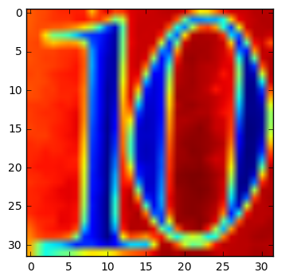

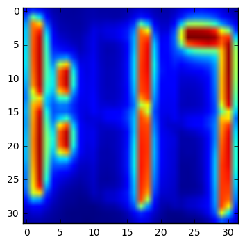

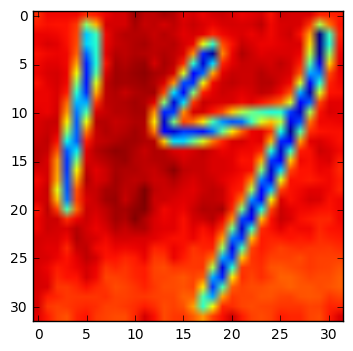

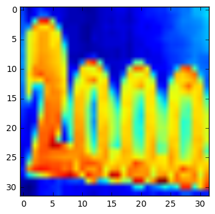

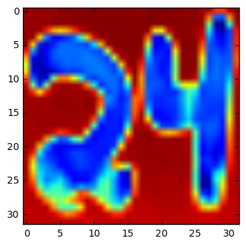

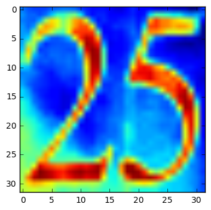

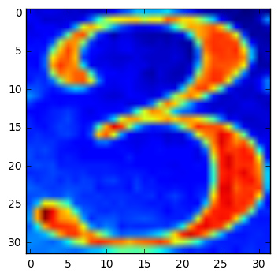

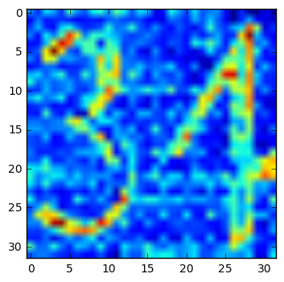

```python
for sample in range(8):
    image = np.array(photos_dataset[sample, 0, :, :])
    plt.figure()
    plt.imshow(image)
```

### Question 8

*Is your model able to perform equally well on captured pictures or a live camera stream when compared to testing on the realistic dataset?*

77% "cropped" digits model: 50% accuracy on photo sequences. Categorical Accuracy: Length: [0.875], Digits: [0.75, 0.625, 1.0, 0.875, 1.0]

28% "whole" digits model: 12.5% accuracy on photo sequences. Categorical Accuracy: Length: [0.375], Digits: [0.5, 0.25, 0.625, 0.875, 1.0]

### Optional: Question 9

*If necessary, provide documentation for how an interface was built for your model to load and classify newly-acquired images.*

**Answer:** Leave blank if you did not complete this part.

## Step 4: Explore an Improvement for a Model

There are many things you can do once you have the basic classifier in place. One example would be to also localize where the numbers are on the image. The SVHN dataset provides bounding boxes that you can tune to train a localizer. Train a regression loss to the coordinates of the bounding box, and then test it.

### Implementation

Use the code cell (or multiple code cells, if necessary) to implement the first step of your project. Once you have completed your implementation and are satisfied with the results, be sure to thoroughly answer the questions that follow.

```python
# Run to load dictionaries

pickle_file = 'SVHN-dictionaries.pickle'

with open(pickle_file, 'rb') as f:
  save = pickle.load(f)
  train_dictionary = save['train_dictionary']
  test_dictionary = save['test_dictionary']
  # extra_dictionary = save['extra_dictionary']
  del save  # hint to help gc free up memory

print("Train dictionary:", len(train_dictionary))
print("Test dictionary:", len(test_dictionary))
# print("Extra dictionary:", len(extra_dictionary))
```

```
Train dictionary: 33402
Test dictionary: 13068
```

```python
# Don't run unless you need to generate a new data set

image_size = 32
pixel_channels = 1
max_sequence_length = 5
num_labels = 11
bbox_dims = 5

def load_images(folder, dictionary):
    image_files = os.listdir(folder)

    dataset = np.ndarray(shape=(len(image_files), pixel_channels, image_size, image_size), dtype=np.int32)
    labels = np.ndarray(shape=(len(image_files), num_labels, max_sequence_length), dtype=np.int32)
    sequences = np.ndarray(shape=(len(image_files), max_sequence_length), dtype=np.int32)
    bboxes = np.ndarray(shape=(len(image_files), max_sequence_length * bbox_dims), dtype=np.float32)

    num_images = 0
    skipped_images = 0
    for image in image_files:
        if image in dictionary:
            label_sequence = dictionary[image]['label']
        else:
            label_sequence = None
            skipped_images += 1

        if len(label_sequence) > max_sequence_length:
            label_sequence = None
            skipped_images += 1
            print("Image", image, "has too many digits!")

        if label_sequence != None and len(label_sequence) > 0:
            image_file = os.path.join(folder, image)
            image_raw = ndimage.imread(image_file, flatten=True)

            lefts = dictionary[image]['left']
            tops = dictionary[image]['top']
            widths = dictionary[image]['width']
            heights = dictionary[image]['height']
            rights = []
            bottoms = []
            for left, width in zip(lefts, widths):
                rights.append(left + width)
            for top, height in zip(tops, heights):
                bottoms.append(top + height)
            if min(tops) < max(bottoms) and min(lefts) < max(rights):
                image_data = image_raw[min(tops):max(bottoms), min(lefts):max(rights)]
            else:
                image_data = image_raw
                print("Bounding box error!")

            if min(image_data.shape) > 0:
                resized_image = imresize(image_data, (image_size, image_size), interp='bilinear')
                dataset[num_images, 0, :, :] = resized_image

                image_shape = image_data.shape
                warp_height = 1. / image_shape[0] # fractional representation of location on image
                warp_width = 1. / image_shape[1]

                labels[num_images, :, :] = 0
                if len(label_sequence) < max_sequence_length:
                    labels[num_images, 0, len(label_sequence):] = 1 # Blank class labels
                    bboxes[num_images, bbox_dims * len(label_sequence):] = 0 # No bounding box present
                for index in range(len(label_sequence)):
                    labels[num_images, label_sequence[index], index] = 1
                    bboxes[num_images, bbox_dims * index + 0] = 1 # Indicates a bounding box is present
                    bboxes[num_images, bbox_dims * index + 1] = (dictionary[image]['top'][index] -
                                                                min(tops)) * warp_height
                    bboxes[num_images, bbox_dims * index + 2] = (dictionary[image]['left'][index] -
                                                                min(lefts)) * warp_width
                    bboxes[num_images, bbox_dims * index + 3] = dictionary[image]['height'][index] * warp_height
                    bboxes[num_images, bbox_dims * index + 4] = dictionary[image]['width'][index] * warp_width

                sequences[num_images, :] = 0
                sequences[num_images, len(label_sequence) - 1] = 1

                num_images += 1
            else:
                skipped_images += 1
                print("Skipped zero-size bbox image:", image)

    print('\nSkipped images:', skipped_images)
    # print('Full dataset tensor:', dataset.shape)
    # print('Mean:', np.mean(dataset))
    # print('Standard deviation:', np.std(dataset), "\n")

    dataset = dataset[0:num_images, :, :, :]
    labels = labels[0:num_images, :, :]
    sequences = sequences[0:num_images, :]
    bboxes = bboxes[0:num_images, :]

    return dataset, labels, sequences, bboxes

train_dataset, train_labels, train_sequences, train_bboxes = load_images('train', train_dictionary)
test_dataset, test_labels, test_sequences, test_bboxes = load_images('test', test_dictionary)
# extra_dataset, extra_labels, extra_sequences = load_images('extra', extra_dictionary)
print("Done.")
```

```
Skipped zero-size bbox image: 11861.png
Skipped zero-size bbox image: 13145.png
Skipped zero-size bbox image: 15125.png
Skipped zero-size bbox image: 18277.png
Skipped zero-size bbox image: 18393.png
Skipped zero-size bbox image: 19383.png
Skipped zero-size bbox image: 20540.png
Skipped zero-size bbox image: 20901.png
Skipped zero-size bbox image: 20915.png
Skipped zero-size bbox image: 22442.png
Skipped zero-size bbox image: 23905.png
Skipped zero-size bbox image: 252.png
Skipped zero-size bbox image: 26570.png
Skipped zero-size bbox image: 27638.png
Skipped zero-size bbox image: 27809.png
Skipped zero-size bbox image: 28513.png
Skipped zero-size bbox image: 28798.png
Skipped zero-size bbox image: 28818.png
Skipped zero-size bbox image: 28850.png
Skipped zero-size bbox image: 29759.png
Image 29930.png has too many digits!
Skipped zero-size bbox image: 30510.png
Skipped zero-size bbox image: 30953.png
Skipped zero-size bbox image: 3100.png
Skipped zero-size bbox image: 32169.png
Skipped zero-size bbox image: 32432.png
Skipped zero-size bbox image: 5312.png
Skipped zero-size bbox image: 6877.png
Skipped zero-size bbox image: 724.png
Skipped zero-size bbox image: 9357.png

Skipped images: 30
Skipped zero-size bbox image: 12434.png
Skipped zero-size bbox image: 2613.png
Skipped zero-size bbox image: 344.png
Skipped zero-size bbox image: 439.png
Skipped zero-size bbox image: 521.png
Skipped zero-size bbox image: 5260.png
Skipped zero-size bbox image: 7636.png
Skipped zero-size bbox image: 8885.png

Skipped images: 8
Done.
```

```python
# Don't run unless you are saving new data

pickle_file = 'SVHN-BB-2.pickle'

try:
    f = open(pickle_file, 'wb')
    save = {
        'train_dataset': train_dataset,
        'train_labels': train_labels,
        'train_sequences': train_sequences,
        'train_bboxes': train_bboxes,
        'test_dataset': test_dataset,
        'test_labels': test_labels,
        'test_sequences': test_sequences,
        'test_bboxes': test_bboxes,
        # 'extra_dataset': extra_dataset,
        # 'extra_labels': extra_labels,
        # 'extra_sequences': extra_sequences,
    }
    pickle.dump(save, f, pickle.HIGHEST_PROTOCOL)
    f.close()
except Exception as e:
    print('Unable to save data to', pickle_file, ':', e)
    raise

statinfo = os.stat(pickle_file)
print('Compressed pickle size:', statinfo.st_size)
```

```
Compressed pickle size: 205973006
```

```python
# Run after import statement to load data

# pickle_file = 'SVHN-BB-1.pickle' # 32x32 greyscale of original images with bounding box info
pickle_file = 'SVHN-BB-2.pickle' # 32x32 greyscale of cropped images with bounding box info

with open(pickle_file, 'rb') as f:
  save = pickle.load(f)
  train_dataset = save['train_dataset']
  train_labels = save['train_labels']
  train_sequences = save['train_sequences']
  train_bboxes = save['train_bboxes']
  test_dataset = save['test_dataset']
  test_labels = save['test_labels']
  test_sequences = save['test_sequences']
  test_bboxes = save['test_bboxes']
  # extra_dataset = save['extra_dataset']
  # extra_labels = save['extra_labels']
  # extra_sequences = save['extra_sequences']
  del save  # hint to help gc free up memory

image_size = 32
num_channels = 1
num_labels = 11
max_sequence_length = 5
bbox_dims = 5

print('Training set', train_dataset.shape, train_labels.shape, train_sequences.shape, train_bboxes.shape)
print('Test set', test_dataset.shape, test_labels.shape, test_sequences.shape, test_bboxes.shape)
# print('Extra set', extra_dataset.shape, extra_labels.shape, extra_sequences.shape)

print('Training sequence distribution:', sum(train_sequences))
print('Testing sequence distribution:', sum(test_sequences))
# print('Extra sequence distribution:', sum(extra_sequences))

print('\n\n', sum(train_labels))
print('\n\n', sum(test_labels))
# print('\n\n', sum(extra_labels))

print('\n\nTrain bounding box means:', np.mean(train_bboxes))
print('Test bounding box means:', np.mean(test_bboxes))
```

```
Training set (33372, 1, 32, 32) (33372, 11, 5) (33372, 5) (33372, 25)
Test set (13060, 1, 32, 32) (13060, 11, 5) (13060, 5) (13060, 25)
Training sequence distribution: [ 5133 18111  8685  1434     9]
Testing sequence distribution: [2482 8350 2080  146    2]


 [[    0  5133 23244 31929 33363]
 [ 9233  3327  1128   156     2]
 [ 6316  3128   983   150     0]
 [ 4342  2966  1057   120     2]
 [ 3509  2807   979   160     0]
 [ 2828  2867  1045   134     1]
 [ 2152  2489   953   130     0]
 [ 1877  2633   960   115     2]
 [ 1582  2378   939   140     0]
 [ 1449  2281   805   121     1]
 [   84  3363  1279   217     1]]


 [[    0  2482 10832 12912 13058]
 [ 3693  1144   244    17     0]
 [ 2655  1232   243    16     0]
 [ 1625  1026   217    13     0]
 [ 1235  1080   198     9     0]
 [ 1051  1078   242    12     0]
 [  856   918   182    17     0]
 [  747  1018   239    12     1]
 [  623   835   192     8     0]
 [  556   848   176    15     0]
 [   19  1399   295    29     1]]


Train bounding box means: 0.2357
Test bounding box means: 0.215693
```

```python
inputs = Input(shape=(num_channels, image_size, image_size))

c1 = Convolution2D(64, 5, 5, border_mode='same')(inputs) # Originally 48
a1 = Activation('relu')(c1)
mp1 = MaxPooling2D(pool_size=(2, 2), strides=(1, 1), border_mode='same')(a1)
bn1 = BatchNormalization()(mp1)

c2 = Convolution2D(96, 5, 5, border_mode='same')(bn1) # Originally 64
a2 = Activation('relu')(c2)
mp2 = MaxPooling2D(pool_size=(2, 2), strides=(2, 2), border_mode='same')(a2)
do2 = Dropout(0.25)(mp2)
bn2 = BatchNormalization()(do2)

c3 = Convolution2D(128, 5, 5, border_mode='same')(bn2)
a3 = Activation('relu')(c3)
mp3 = MaxPooling2D(pool_size=(2, 2), strides=(1, 1), border_mode='same')(a3)
do3 = Dropout(0.25)(mp3)
bn3 = BatchNormalization()(do3)

c4 = Convolution2D(160, 5, 5, border_mode='same')(bn3)
a4 = Activation('relu')(c4)
mp4 = MaxPooling2D(pool_size=(2, 2), strides=(2, 2), border_mode='same')(a4)
do4 = Dropout(0.25)(mp4)
bn4 = BatchNormalization()(do4)

c5 = Convolution2D(192, 5, 5, border_mode='same')(bn4)
a5 = Activation('relu')(c5)
mp5 = MaxPooling2D(pool_size=(2, 2), strides=(1, 1), border_mode='same')(a5)
do5 = Dropout(0.25)(mp5)
bn5 = BatchNormalization()(do5)

c6 = Convolution2D(192, 5, 5, border_mode='same')(bn5)
a6 = Activation('relu')(c6)
mp6 = MaxPooling2D(pool_size=(2, 2), strides=(2, 2), border_mode='same')(a6)
do6 = Dropout(0.25)(mp6)
bn6 = BatchNormalization()(do6)

c7 = Convolution2D(192, 5, 5, border_mode='same')(bn6)
a7 = Activation('relu')(c7)
mp7 = MaxPooling2D(pool_size=(2, 2), strides=(1, 1), border_mode='same')(a7)
do7 = Dropout(0.25)(mp7)
bn7 = BatchNormalization()(do7)

c8 = Convolution2D(192, 5, 5, border_mode='same')(bn7)
a8 = Activation('relu')(c8)
mp8 = MaxPooling2D(pool_size=(2, 2), strides=(2, 2), border_mode='same')(a8)
do8 = Dropout(0.25)(mp8)
bn8 = BatchNormalization()(do8)

fl = Flatten()(bn8)

d1 = Dense(3096)(fl)
a9 = Activation('relu')(d1)
do9 = Dropout(0.25)(a9)
bn9 = BatchNormalization()(do9)

d3 = Dense(max_sequence_length)(bn9)
bn10 = BatchNormalization()(d3)
L = Activation('softmax')(bn10) # <--- Sequence length representation

d4 = Dense(num_labels)(bn9)
bn11 = BatchNormalization()(d4)
S1 = Activation('softmax')(bn11) # First character/digit

d5 = Dense(num_labels)(bn9)
bn12 = BatchNormalization()(d5)
S2 = Activation('softmax')(bn12)

d6 = Dense(num_labels)(bn9)
bn13 = BatchNormalization()(d6)
S3 = Activation('softmax')(bn13)

d7 = Dense(num_labels)(bn9)
bn14 = BatchNormalization()(d7)
S4 = Activation('softmax')(bn14)

d8 = Dense(num_labels)(bn9)
bn15 = BatchNormalization()(d8)
S5 = Activation('softmax')(bn15)

d9 = Dense(bbox_dims * max_sequence_length)(bn9)
bn16 = BatchNormalization()(d9)
BB = Activation('sigmoid')(bn16)

clf = Model(input=inputs, output=[L, S1, S2, S3, S4, S5, BB]) # Seq length + five channel output + bounding box

clf.compile(loss=['categorical_crossentropy', 'categorical_crossentropy', 'categorical_crossentropy',
                  'categorical_crossentropy', 'categorical_crossentropy', 'categorical_crossentropy',
                  'mean_squared_error'], optimizer='adadelta', metrics=['categorical_accuracy'])

clf.fit(train_dataset, [train_sequences, train_labels[:,:,0], train_labels[:,:,1], train_labels[:,:,2],
                        train_labels[:,:,3], train_labels[:,:,4], train_bboxes],
                        batch_size=100, nb_epoch=1400, validation_split=0.03, verbose=0)

clf.save('SVHN-BB-2.h5')

print("Training complete.")
```

```
Training complete.
```

```python
clf = load_model('SVHN-BB-2.h5') # Train dataset with bboxes, conv: [64, 96, 128, 160], dense: [3096], 1400 epochs
# clf.summary()

evaluate = clf.evaluate(test_dataset, [test_sequences, test_labels[:,:,0], test_labels[:,:,1],
                            test_labels[:,:,2], test_labels[:,:,3], test_labels[:,:,4], test_bboxes])

print("\n", evaluate)

print("\n", getAccuracy(clf, test_dataset, test_sequences, test_labels))
```

[output not shown]

```python
clf = load_model('SVHN-BB-2.h5') # Train dataset with bboxes, conv: [64, 96, 128, 160], dense: [3096], 1400 epochs

print("\n", getAccuracy(clf, photos_dataset, photos_sequences, photos_labels))
```

```
 0.375
```

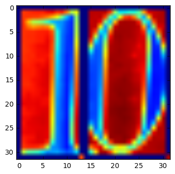

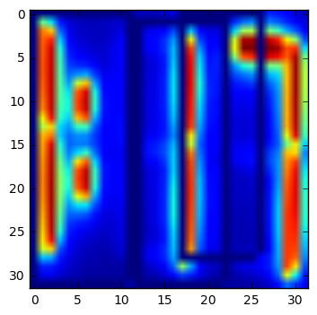

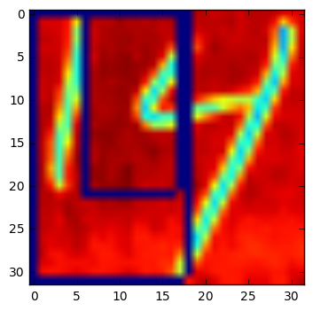

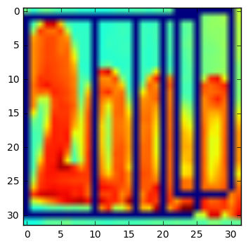

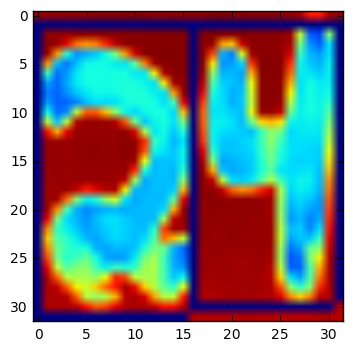

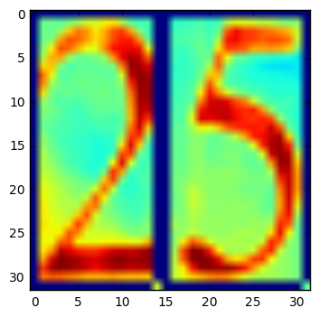

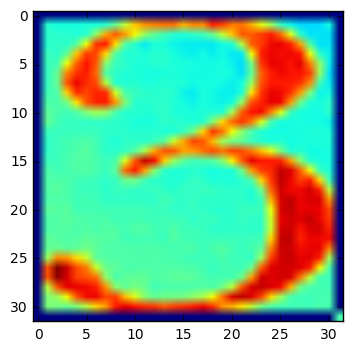

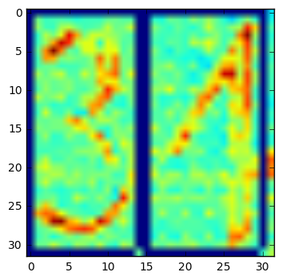

```python
preds = clf.predict(photos_dataset)

for sample in range(8):
    # print(preds[6][sample][0:5])
    # print(preds[6][sample][5:10])
    # print(preds[6][sample][10:15])
    # print(preds[6][sample][15:20])
    # print(preds[6][sample][20:25])

    image = np.array(photos_dataset[sample, 0, :, :])
    # plt.figure()
    # plt.imshow(image)

    for index in range(max_sequence_length):
        if preds[6][sample][5 * index + 0] > 0.5:
            top = int(32 * preds[6][sample][5 * index + 1])
            left = int(32 * preds[6][sample][5 * index + 2])
            bottom = int(32 * (preds[6][sample][5 * index + 3] + preds[6][sample][5 * index + 1]))
            right = int(32 * (preds[6][sample][5 * index + 4] + preds[6][sample][5 * index + 2]))
            image[top:bottom, left] = 0
            image[top:bottom, right] = 0
            image[top, left:right] = 0
            image[bottom, left:right] = 0

    plt.figure()
    plt.imshow(image)
```

### Question 10

*How well does your model localize numbers on the testing set from the realistic dataset? Do your classification results change at all with localization included?*

**Answer:** I used the uncropped images that previously could only be identified with ~27% accuracy and added the bounding boxes as an additionaly 25-node output (5 channels x 5 parameters per box). After 100 epochs the network reached the same ~24% accuracy that the model had reached at that point without the bounding box information.

The model trained using cropped images achieves marginally higher accuracy (77.7%) when using the bounding box information as an additional set of outputs.

The classification results do not change significantly with localization included.

### Question 11

*Test the localization function on the images you captured in **Step 3**. Does the model accurately calculate a bounding box for the numbers in the images you found? If you did not use a graphical interface, you may need to investigate the bounding boxes by hand.* Provide an example of the localization created on a captured image.

**Answer:** The network trained including the bounding box information actually missed one extra image and now has an accuracy of 37.5% instead of 50%.

The bounding box information isn't perfect, but reasonably identifies the presence and location of the digits in most of the photos above.

## Optional Step 5: Build an Application or Program for a Model

Take your project one step further. If you're interested, look to build an Android application or even a more robust Python program that can interface with input images and display the classified numbers and even the bounding boxes. You can for example try to build an augmented reality app by overlaying your answer on the image like the [Word Lens](https://en.wikipedia.org/wiki/Word_Lens) app does.

Loading a TensorFlow model into a camera app on Android is demonstrated in the [TensorFlow Android demo app](https://github.com/tensorflow/tensorflow/tree/master/tensorflow/examples/android), which you can simply modify.

If you decide to explore this optional route, be sure to document your interface and implementation, along with significant results you find. You can see the additional rubric items that you could be evaluated on by [following this link](https://review.udacity.com/#!/rubrics/413/view).

### Optional Implementation

Use the code cell (or multiple code cells, if necessary) to implement the first step of your project. Once you have completed your implementation and are satisfied with the results, be sure to thoroughly answer the questions that follow.

```python
### Your optional code implementation goes here.
### Feel free to use as many code cells as needed.
```

### Documentation

Provide additional documentation sufficient for detailing the implementation of the Android application or Python program for visualizing the classification of numbers in images. It should be clear how the program or application works. Demonstrations should be provided.

*Write your documentation here.*

> **Note**: Once you have completed all of the code implementations and successfully answered each question above, you may finalize your work by exporting the iPython Notebook as an HTML document. You can do this by using the menu above and navigating to  
> **File -> Download as -> HTML (.html)**. Include the finished document along with this notebook as your submission.